# Chapter 5: Advanced PA Techniques & Future Directions

PA Design Reference Manual

2026-02-01

# 1 Introduction

## 1.1 Chapter Overview

This chapter explores advanced power amplifier techniques that extend beyond the baseline Doherty PA implementation covered in previous chapters. We examine efficiency enhancement architectures, linearization systems, advanced packaging technologies, and emerging trends shaping the future of PA design.

**Key Topics**:

- **Doherty Architecture Deep Dive**: Advanced variants and optimization
- **Envelope Tracking (ET)**: Ultimate efficiency through dynamic supply modulation
- **Digital Pre-Distortion (DPD)**: Linearization for complex modulation
- **Advanced Packaging**: Integration and thermal management
- **GaN Technology Evolution**: Wide bandgap semiconductor trends
- **6G & Future Technologies**: Preparing for next-generation systems
- **AI/ML in PA Design**: Intelligent optimization and adaptation

**Learning Objectives**:

By the end of this chapter, you should be able to:

1. Explain advanced efficiency enhancement techniques and their trade-offs
2. Understand linearization system architectures and DPD algorithms
3. Evaluate packaging options for PA integration
4. Assess emerging GaN technologies and their impact
5. Anticipate future PA design challenges for 6G and beyond
6. Apply AI/ML concepts to PA optimization

# 2 Advanced Efficiency Enhancement Techniques

## 2.1 Doherty Architecture Deep Dive

### 2.1.1 Fundamental Doherty Theory

The Doherty power amplifier, invented by William H. Doherty in 1936, remains one of the most elegant efficiency enhancement techniques for RF power amplifiers. The key innovation is **load modulation** - dynamically adjusting the load impedance presented to the main (carrier) amplifier as output power varies.

#### 2.1.1.1 Basic Doherty Operation

**Low Power Region (< 6 dB backoff)**: - Main amplifier active, operating in saturation region - Peak amplifier OFF (below threshold) - Load impedance to main amplifier: $Z_{opt} \times 2$ (high impedance) - Efficiency maintained through reduced current at lower voltage swing

**High Power Region (> 6 dB backoff to peak)**: - Main amplifier saturated at constant output power - Peak amplifier turns ON, begins contributing power - Load modulation: Peak amplifier current reduces main amplifier’s load impedance - At peak power: Both amplifiers see $Z_{opt}$ and deliver rated power - Main amplifier efficiency remains high despite increased power

**Mathematical Foundation**:

Load impedance at main amplifier drain:
$$Z_{main}(P_{out}) = Z_{opt} \left(1 +
\frac{I_{peak}}{I_{main}}\right)$$

**Variable Definitions**:

- $Z_{main}(P_{out})$ [Ω] = Effective load impedance seen by main amplifier as function of output power
- $Z_{opt}$ [Ω] = Optimal load impedance for maximum power and efficiency (typically 5-20Ω for GaN devices)
- $I_{main}$ [A] = Main amplifier drain current (remains constant when saturated)
- $I_{peak}$ [A] = Peak amplifier drain current (zero at low power, increases at high power)
- $P_{out}$ [W or dBm] = Total output power from combined Doherty PA

[figure not shown]

Figure 5.1a: Doherty Load Modulation Mechanism

Peak amplifier current relationship:
$$I_{peak}(P_{out}) = \begin{cases}
0 & P_{out} < P_{peak}/4 \text{ (6 dB backoff)} \\
\sqrt{\frac{4P_{out}}{Z_{opt}} - I_{main}^2} & P_{out} \geq
P_{peak}/4
\end{cases}$$

**Variable Definitions**:

- $I_{peak}(P_{out})$ [A] = Peak amplifier drain current as function of output power
- $P_{out}$ [W] = Total output power from Doherty PA system
- $P_{peak}$ [W] = Maximum output power capability of Doherty PA
- $P_{peak}/4$ [W] = Power level at 6 dB backoff (where peak amplifier turns on)
- $Z_{opt}$ [Ω] = Optimal load impedance for transistor devices
- $I_{main}$ [A] = Main amplifier saturated drain current (constant)

**Physical Interpretation**: - **Below 6 dB backoff** ($P_{out} < P_{peak}/4$): Peak amplifier is biased OFF (Class C, below threshold), contributing zero current - **Above 6 dB backoff** ($P_{out} \geq P_{peak}/4$): Peak amplifier turns ON and its current increases according to square-root relationship, which comes from power-current relationship: $P = I^2 Z / 2$ for sinusoidal signals - The term $\sqrt{4P_{out}/Z_{opt}}$ represents total current needed to deliver $P_{out}$ - Subtracting $I_{main}^2$ under the radical accounts for main amplifier’s contribution

Theoretical efficiency at 6 dB backoff:
$$\eta_{6dB} = \frac{\pi}{4} \times \eta_{peak}
\approx 0.785 \times \eta_{peak}$$

**Variable Definitions**:

- $\eta_{6dB}$ [%] = Power-added efficiency (PAE) at 6 dB backoff from peak power
- $\eta_{peak}$ [%] = Maximum PAE at peak output power
- $\pi/4 \approx 0.785$ [dimensionless] = Mathematical constant arising from Class B theoretical efficiency vs conduction angle

**Physical Interpretation**: This remarkable result shows Doherty PA maintains ~78.5% of its peak efficiency even at 6 dB backoff, compared to ~38% for classical Class AB (which drops by 6 dB in both numerator and denominator). The $\pi/4$ factor comes from Fourier analysis of half-sine current waveforms in Class B operation.

For a Class AB PA with $\eta_{peak} = 65\%$: - Traditional Class AB at 6 dB backoff: ~30% PAE - Doherty at 6 dB backoff: ~50% PAE - **Improvement: 67% relative gain in efficiency**

### 2.1.2 Design Parameters

#### 2.1.2.1 Impedance Transformation Network

The **offset line** (or impedance inverter) between main device and combining point is critical:

**Electrical Length**: $\theta = 90°$ at center frequency $f_0$

**Characteristic Impedance**:
$$Z_0 = \sqrt{Z_{opt} \times R_L}$$

**Variable Definitions**:

- $Z_0$ [Ω] = Characteristic impedance of quarter-wave offset line (impedance inverter)
- $Z_{opt}$ [Ω] = Optimal load impedance for transistor device (determined by load-pull)
- $R_L$ [Ω] = System load resistance (50Ω for RF systems, antenna impedance)

**Physical Interpretation**: The quarter-wave transmission line acts as an **impedance inverter**, transforming $R_L$ at the load end to $Z_0^2/R_L$ at the device end. The geometric mean $\sqrt{Z_{opt} \times R_L}$ ensures proper impedance transformation at center frequency. This is derived from transmission line theory where a $\lambda/4$ line with $Z_0$ transforms impedance as: $Z_{in} = Z_0^2 / Z_{load}$.

**Design Example**: For a 10Ω device to 50Ω system:
$$Z_0 = \sqrt{10 \times 50} = \sqrt{500} =
22.4 \text{ Ω}$$

Verification: $Z_{in} = Z_0^2 / R_L = (22.4)^2 / 50 = 501.76 / 50 \approx 10Ω$ ✓

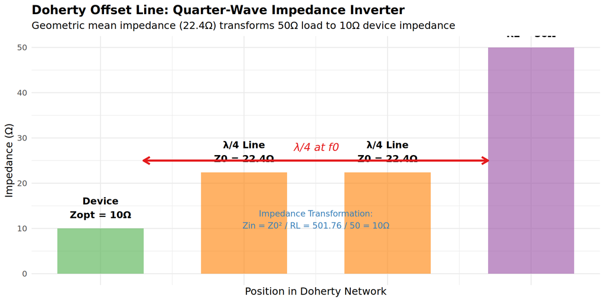

Figure 5.1b: Quarter-Wave Offset Line Impedance Transformation

**Practical Implementation**: - Microstrip line width calculated for 22.4Ω - Length = $\lambda_g/4$ at $f_0$ (including via and pad parasitics) - Substrate: Rogers RO4350B ($\epsilon_r = 3.48$, h = 0.76mm)

#### 2.1.2.2 Device Sizing Ratio

**Symmetric Doherty**: Main : Peak = 1:1 - Equal device sizes - Simpler design, easier to balance - 6 dB efficiency peak at backoff

**Asymmetric Doherty**: Main : Peak = 2:1 or 3:1 - Larger main device - Efficiency peak adjusts: 2:1 → 4.8 dB, 3:1 → 4.3 dB - Better match to signal statistics - More complex impedance transformations

**Design Trade-off**:

Table 5.1: Doherty Asymmetry Trade-offs

| Main:Peak Ratio | Backoff (dB) | Peak PAE (%) | Backoff PAE (%) | Complexity (rel.) | Bandwidth (% rel.) |
| --- | --- | --- | --- | --- | --- |
| 1:1 | 6.0 | 65 | 50 | 1.0 | 100 |
| 2:1 | 4.8 | 66 | 52 | 1.3 | 85 |
| 3:1 | 4.3 | 65 | 51 | 1.6 | 75 |
| 4:1 | 4.0 | 63 | 48 | 2.0 | 70 |

#### 2.1.2.3 Bias Point Selection

**Main Amplifier**: Class AB - $V_{GS}$ = Threshold + 0.5-1.5V - Quiescent current: 5-15% of $I_{max}$ - **Always ON**, never fully turns off - Provides constant gain, acts as driver for peak path

**Peak Amplifier**: Deep Class C - $V_{GS}$ = Threshold - 0.2 to -0.5V (below threshold) - Quiescent current: <1% of $I_{max}$ (ideally 0mA) - Turns ON only at high input power (>6 dB backoff) - Gate voltage swing must exceed threshold

**Critical Design Point**: Peak amplifier turn-on threshold
$$V_{GS,peak}(turn-on) = V_{th} +
V_{RF} \times \sqrt{\frac{P_{in}}{P_{in,peak}}}$$

### 2.1.3 Advanced Doherty Variants

#### 2.1.3.1 Three-Way Doherty

**Architecture**: One main + Two peak amplifiers - First peak turns ON at 9 dB backoff - Second peak turns ON at 4.5 dB backoff - Three efficiency peaks across power range

**Advantages**: - Excellent efficiency at 9 dB backoff (critical for 5G NR) - Matches modern signal PAPR better - 10-15% average efficiency improvement over 2-way

**Challenges**: - Complex impedance network (two offset lines) - Phase synchronization across three paths - Larger die area and cost

**Design Equations**:

For 1:1:1 sizing, load impedances:
$$Z_{main,low} = 3 \times Z_{opt}$$
$$Z_{main,mid} = 1.5 \times Z_{opt}$$
$$Z_{main,high} = Z_{opt}$$

Offset line impedances:
$$Z_{01} =
\sqrt{Z_{opt} \times 1.5 \times Z_{opt}} \approx 1.22 \times
Z_{opt}$$
$$Z_{02} = \sqrt{1.5 \times
Z_{opt} \times R_L}$$

#### 2.1.3.2 Inverted Doherty

**Key Innovation**: Peak amplifier directly connected to load, main amplifier uses offset line

**Advantages**: - Simplified output matching for peak device - Better high-power performance - Easier to implement post-matching

**When to Use**: - Peak device larger or more sensitive to impedance - Output power priority over backoff efficiency - Wideband implementations

#### 2.1.3.3 Digital Doherty

**Concept**: Replace analog impedance inverter with digital control - Active load modulation using tunable matching networks - MEMS or BST varactors adjust impedance - Software-defined load trajectories

**Benefits**: - Bandwidth extension (no quarter-wave limitation) - Adaptive optimization per frequency - Compensation for temperature/aging

**Challenges**: - Added complexity and cost - Tuning element losses - Control algorithm development - Limited power handling of tunable elements

### 2.1.4 Bandwidth Limitations & Extension

#### 2.1.4.1 Quarter-Wave Line Issue

**Problem**: Offset line is $\lambda_g/4$ only at one frequency

At $f \neq f_0$:
$$\theta(f) = 90° \times \frac{f}{f_0}$$

**Impact**: - At $f = 0.8 f_0$: $\theta = 72°$ → impedance transformation degraded - At $f = 1.2 f_0$: $\theta = 108°$ → load modulation corrupted - Typical Doherty bandwidth: 10-20% fractional

**Bandwidth Extension Techniques**:

1. **Modified Offset Line**:
   - Non-uniform transmission line
   - Tapered impedance profile
   - Extends BW to ~30%
2. **Dual-Band Offset Line**:
   - Cascaded quarter-wave sections
   - Multiple resonances
   - For discrete bands (e.g., n77 + n79 in 5G)
3. **Post-Matching Network**:
   - Additional matching after Doherty combining
   - Absorbs frequency-dependent impedance variations
   - Passive or active (tunable)
4. **Integrated Compensating Network**:
   - Phase compensator in peak path
   - Equalizes delay differences vs frequency
   - Maintains load modulation across band

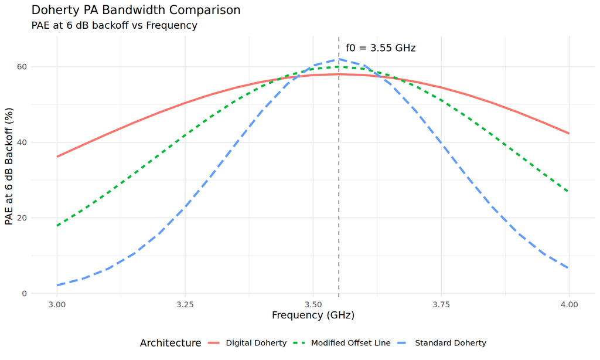

Figure 5.1: Doherty Bandwidth Limitation & Extension Techniques

## 2.2 Envelope Tracking (ET)

Envelope Tracking represents the **ultimate efficiency enhancement technique** by dynamically modulating the PA supply voltage to track the signal envelope, ensuring the PA always operates at or near compression.

### 2.2.1 ET System Architecture

**Core Components**:

1. **Envelope Detector**: Extracts amplitude from I/Q baseband
2. **Envelope Amplifier (EA)**: Generates time-varying supply voltage
3. **RF Power Amplifier**: Operates with modulated $V_{DD}$
4. **Delay Alignment**: Synchronizes envelope and RF paths

**System Block Diagram**:

```
I/Q Baseband → [Envelope] → [Supply]   ↓ V_DD(t)
                 Detector     Modulator

I/Q Baseband → [RF PA] → [Matching] → RF Out
               w/ET
```

### 2.2.2 Envelope Shaping Function

The relationship between signal envelope and supply voltage is not simply linear. The **shaping function** $V_{DD}(envelope)$ optimizes efficiency while maintaining linearity.

**Common Shaping Functions**:

1. **Linear Shaping**:
   $$V_{DD}(t) = V_{min} + (V_{max} - V_{min}) \times
   |envelope(t)|$$

**Variable Definitions**: - $V_{DD}(t)$ [V] = Time-varying supply voltage to PA drain - $V_{min}$ [V] = Minimum supply voltage (at signal envelope minimum, typically 10-20% of $V_{max}$) - $V_{max}$ [V] = Maximum supply voltage (at peak envelope, equals PA rated voltage, e.g., 48V for GaN) - $|envelope(t)|$ [dimensionless, 0 to 1] = Normalized signal envelope magnitude, where $|envelope(t)| = \sqrt{I(t)^2 + Q(t)^2} / max(\sqrt{I^2 + Q^2})$ - $t$ [s] = Time

2. **Piecewise Linear Shaping**:
   $$V_{DD}(t) = \begin{cases}
   V_{min} & |env| < Threshold \\
   V_{min} + k_1 \times (|env| - Threshold) & Threshold \leq |env| <
   Knee \\
   V_{mid} + k_2 \times (|env| - Knee) & |env| \geq Knee
   \end{cases}$$

**Variable Definitions**: - $|env|$ [dimensionless, 0 to 1] = Normalized envelope magnitude (shorthand for $|envelope(t)|$) - $Threshold$ [dimensionless, typically 0.1-0.2] = Envelope level below which $V_{DD}$ held constant at $V_{min}$ - $Knee$ [dimensionless, typically 0.5-0.7] = Envelope level where piecewise function changes slope - $k_1$ [V] = Slope in first linear region (lower power), typically $(V_{mid} - V_{min}) / (Knee - Threshold)$ - $k_2$ [V] = Slope in second linear region (higher power), typically $(V_{max} - V_{mid}) / (1 - Knee)$ - $V_{mid}$ [V] = Supply voltage at knee point, intermediate value between $V_{min}$ and $V_{max}$

**Physical Interpretation**: Two-slope function reduces supply modulator bandwidth requirement while maintaining efficiency. Shallower slope at low power prevents excessive voltage swing for small envelope variations.

3. **Polynomial Shaping** (2nd or 3rd order):
   $$V_{DD}(t) = a_0 + a_1 \times |env| + a_2 \times
   |env|^2 + a_3 \times |env|^3$$

**Variable Definitions**: - $a_0$ [V] = Constant term, typically equals $V_{min}$ (y-intercept) - $a_1$ [V] = Linear coefficient, dominant term - $a_2$ [V] = Quadratic coefficient, adds curvature (positive value creates upward bow) - $a_3$ [V] = Cubic coefficient, fine-tunes high-power region - Constraint: $a_0 + a_1 + a_2 + a_3 = V_{max}$ (at $|env| = 1$)

**Physical Interpretation**: Polynomial shaping optimized through measurement/simulation to minimize ACLR while maximizing efficiency. Coefficients determined by multi-objective optimization.

**Optimization Goal**: Maximize efficiency while meeting linearity (ACLR/EVM) specs

**Typical Values** (GaN PA, 3.5 GHz, 5G NR): - $V_{min}$ = 12V (at low power, 10 dB backoff) - $V_{max}$ = 48V (at peak power) - Polynomial coefficients determined through characterization

### 2.2.3 Supply Modulator Topologies

#### 2.2.3.1 Linear EA (Class AB/G/H)

**Advantages**: - Excellent linearity and bandwidth - Low distortion - Simple control

**Disadvantages**: - Low efficiency (40-60%) - Significant heat dissipation - Limits overall system gain

**When to Use**: Low to medium power applications (<20W), ultra-wideband

#### 2.2.3.2 Switched-Mode EA (Buck Converter)

**Advantages**: - High efficiency (80-90%) - Scalable to high power - Lower thermal load

**Disadvantages**: - Limited bandwidth (typically <20 MHz envelope BW) - Switching noise - More complex control

**When to Use**: Medium to high power (>20W), moderate BW signals

#### 2.2.3.3 Hybrid EA (Linear + Switched)

**Architecture**: Parallel combination - Switched-mode supplies average/low-frequency envelope - Linear amp supplies high-frequency envelope components

**Performance**: - Efficiency: 65-75% - Bandwidth: 50-100 MHz envelope BW - Best compromise for wideband 5G

**Design Challenge**: Current distribution between paths

### 2.2.4 Bandwidth & Slew Rate Requirements

**Envelope Bandwidth** is much wider than RF channel bandwidth due to modulation statistics.

For 5G NR 100 MHz channel (256-QAM): - **Baseband I/Q bandwidth**: 100 MHz - **Envelope bandwidth**: ~200 MHz (due to $|I + jQ|$ rectification) - **ET modulator requirement**: >200 MHz, ideally 300-400 MHz

**Slew Rate Requirement**:
$$SR = \frac{dV_{DD}}{dt}_{max} = (V_{max} -
V_{min}) \times 2\pi \times BW_{env}$$

**Variable Definitions**:

- $SR$ [V/s or V/µs] = Slew rate, maximum rate of change of supply voltage
- $dV_{DD}/dt$ [V/s] = Time derivative of supply voltage (instantaneous rate of change)
- $V_{max}$ [V] = Maximum supply voltage (e.g., 48V for GaN PA)
- $V_{min}$ [V] = Minimum supply voltage (e.g., 12V for GaN PA)
- $(V_{max} - V_{min})$ [V] = Peak-to-peak voltage swing that modulator must track
- $BW_{env}$ [Hz] = Envelope bandwidth (maximum frequency component in envelope signal)
- $2\pi \times BW_{env}$ [rad/s] = Angular frequency of highest envelope component

**Physical Interpretation**: Slew rate represents worst-case scenario when envelope signal changes from minimum to maximum (or vice versa) at the fastest possible rate, which occurs at the envelope bandwidth frequency. The $2\pi$ factor converts frequency to angular frequency. This is analogous to maximum velocity of sinusoidal motion: $v_{max} = A \omega$ where amplitude $A = (V_{max} - V_{min})/2$ and $\omega = 2\pi f$.

**Practical Challenge**: Few commercial supply modulators achieve >20 kV/µs slew rate, requiring bandwidth limiting of envelope signal (accept slight efficiency loss) or advanced hybrid modulators.

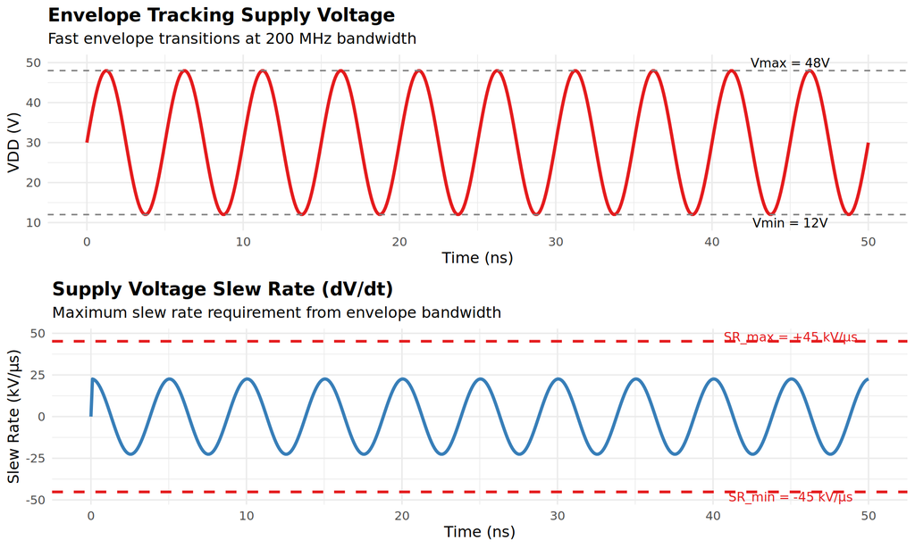

Figure 5.2: Envelope Tracking Slew Rate Requirement

**Practical Limitation**: Few supply modulators achieve >20 kV/µs - **Solution**: Bandwidth limiting filter on envelope path - **Trade-off**: Slight efficiency loss but manageable with DPD

### 2.2.5 ET Efficiency Analysis

**System Efficiency**:
$$\eta_{ET,system} = \eta_{PA} \times
\eta_{modulator} \times \eta_{alignment}$$

**Variable Definitions**:

- $\eta_{ET,system}$ [%] = Overall envelope tracking system efficiency (DC power in to RF power out)
- $\eta_{PA}$ [%] = RF power amplifier efficiency with ET (drain efficiency or PAE)
- $\eta_{modulator}$ [%] = Supply modulator efficiency (AC mains to DC variable voltage)
- $\eta_{alignment}$ [dimensionless, 0.95-0.99] = Efficiency penalty due to imperfect time alignment between RF and envelope paths (typically 1-5% loss)

**Physical Interpretation**: - Total system efficiency is **product** (not sum) of component efficiencies - Even with high PA efficiency (~70%), poor modulator efficiency (~50%) yields mediocre system performance (~35%) - Time misalignment causes PA to operate at non-optimal $V_{DD}$ for instantaneous envelope → efficiency loss - **Key Insight**: ET only beneficial when modulator efficiency >65%, otherwise Doherty architecture preferred

**PA Efficiency** (with ideal ET): - Always near compression → $\eta_{PA} \approx 60-70\%$ at all power levels - Compare to Doherty: ~50% at 6 dB backoff, ~35% at 9 dB backoff

**Modulator Efficiency**: - Linear: $\eta_{mod} = 40-60\%$ - Switched: $\eta_{mod} = 80-90\%$ - Hybrid: $\eta_{mod} = 65-75\%$

**Overall System Efficiency**: - Linear ET: $0.65 \times 0.50 = 32\%$ (worse than Doherty!) - Hybrid ET: $0.68 \times 0.70 = 48\%$ (comparable to Doherty) - Switched ET: $0.65 \times 0.85 = 55\%$ (**superior to Doherty**)

**Conclusion**: ET only worthwhile with efficient supply modulator

### 2.2.6 Time Alignment

**Critical Challenge**: RF and envelope paths have different delays

**Typical Delay Mismatch**: - RF path: ~1-2 ns (mainly PA group delay) - Envelope path: 5-20 ns (detector + modulator delays)

**Alignment Techniques**:

**Calibration**: - Sweep delay setting - Measure ACLR or EVM - Optimal delay at minimum distortion

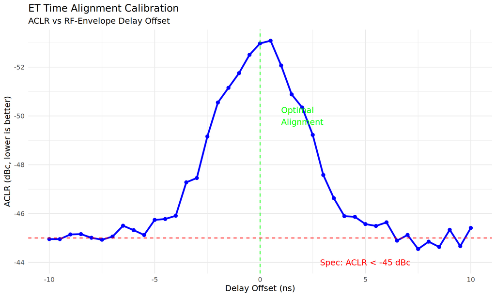

Figure 5.2: ET Time Alignment Impact on Linearity

### 2.2.7 ET vs Doherty Comparison

Table 5.2: Doherty vs Envelope Tracking Comparison

| Parameter | Doherty PA | ET (Hybrid Modulator) | ET (Switched Modulator) |
| --- | --- | --- | --- |
| Peak Efficiency | 65% | 68% | 65% |
| 6 dB Backoff Efficiency | 50% | 55% | 58% |
| 9 dB Backoff Efficiency | 35% | 45% | 50% |
| Average Efficiency (8 dB PAPR) | 40-45% | 48-53% | 52-57% |
| Bandwidth Capability | 10-20% (standard), 30% (extended) | 40-60% (limited by modulator) | 20-30% (converter BW limit) |
| Linearity | Good (with DPD) | Excellent (with alignment) | Good (requires careful design) |
| Complexity | Medium | High | Very High |
| Cost | Medium | High | High |
| Reliability | High (passive) | Medium (active components) | Medium |
| Market Maturity | Mature | Growing | Emerging |

**Recommendation**: - **Macro base station (>40W)**: ET with switched or hybrid modulator - Efficiency savings justify complexity and cost - Cooling requirements reduced significantly

- **Small cell (10-40W)**: Doherty or ET hybrid
  - Doherty simpler, proven technology
  - ET if bandwidth >30% required
- **Handset (<5W)**: Average Power Tracking (APT) or ET
  - Battery life critical
  - APT: Simplified ET with ms-scale supply modulation

## 2.3 Digital Pre-Distortion (DPD)

Digital Pre-Distortion is the **enabler for modern PAs** with complex modulation formats. By predistorting the input signal, DPD compensates for PA nonlinearity, achieving linear amplification while operating the PA in its most efficient (nonlinear) region.

### 2.3.1 DPD System Architecture

**Components**:

1. **Observation Path**: Coupler + downconverter to capture PA output
2. **Model Identification**: Extract PA characteristics from input-output data
3. **Pre-Distorter**: Apply inverse function to baseband I/Q
4. **Adaptation**: Update DPD coefficients in real-time

**Feedback Loop**:

```
I/Q Input → [DPD] → [PA] → [Coupler] → RF Out
              ↑              ↓
              └── [Adapt] ←─ [Obs RX]
```

### 2.3.2 PA Nonlinearity Models

#### 2.3.2.1 Memoryless Polynomial Model

**Simplest model**: Assumes PA output depends only on instantaneous input

**AM-AM (Amplitude compression)**:
$$|y(t)| = \sum_{n=0}^{N} a_n \times
|x(t)|^n$$

**AM-PM (Phase distortion)**:
$$\angle y(t) = \angle x(t) + \sum_{n=0}^{N} b_n
\times |x(t)|^n$$

**Typical Order**: N = 5 to 9 (odd terms dominate due to symmetry)

**Limitation**: Ignores memory effects

#### 2.3.2.2 Memory Polynomial Model

**Enhanced model**: Includes time-dependent behavior

$$y(t) = \sum_{n=0}^{N} \sum_{m=0}^{M}
h_{n,m} \times x(t-m) \times |x(t-m)|^{n-1}$$

Where: - $N$ = Nonlinearity order (e.g., 9) - $M$ = Memory depth (e.g., 5 samples) - $h_{n,m}$ = Complex coefficients

**Captures**: - Self-heating (thermal time constants) - Bias network dynamics - Trap effects in GaN

**Typical Values for GaN PA**: - Memory depth: 3-7 samples - At 491 MSPS: ~6-14 ns memory span - Sufficient for most 5G waveforms

#### 2.3.2.3 Generalized Memory Polynomial (GMP)

**Most comprehensive**:
$$y(t) = \sum_{n=0}^{N_a} \sum_{m=0}^{M_a} a_{n,m}
x(t-m)|x(t-m)|^{n-1}$$
$$+
\sum_{n=0}^{N_b} \sum_{m=1}^{M_b} \sum_{l=1}^{L_b} b_{n,m,l}
x(t-m)|x(t-m-l)|^{n-1}$$
$$+
\sum_{n=0}^{N_c} \sum_{m=1}^{M_c} \sum_{l=1}^{L_c} c_{n,m,l}
x(t-m)|x(t-m+l)|^{n-1}$$

**Three Components**: - **Aligned terms**: $a_{n,m}$ (standard memory polynomial) - **Lagging cross-terms**: $b_{n,m,l}$ (signal envelope from past affects current) - **Leading cross-terms**: $c_{n,m,l}$ (future envelope affects current via memory)

**Complexity**: 100-300 coefficients typical **Performance**: Best linearity, but high computational cost

### 2.3.3 Model Identification (Training)

**Goal**: Determine DPD coefficients from calibration data

**Procedure**:

1. **Capture Training Data**:
   - Apply test signal (5G NR waveform)
   - Record input $x[n]$ and output $y[n]$ samples
   - Typically 100k-1M samples per training iteration
2. **Construct Regression Matrix**:
   - Build matrix $\mathbf{X}$ from input samples and nonlinear terms
   - Size: [samples × coefficients]
3. **Least Squares Solution**:
   $$\mathbf{h} = (\mathbf{X}^H \mathbf{X})^{-1}
   \mathbf{X}^H \mathbf{y}$$

   Where $\mathbf{h}$ = coefficient vector
4. **Apply DPD**:
   - Pre-distort input: $x_{PD}[n] = DPD(x[n], \mathbf{h})$
   - Measure output linearity
5. **Iterate** (indirect learning):
   - Update coefficients based on residual error
   - Typically converges in 3-10 iterations

**Convergence Metric**: NMSE (Normalized Mean Square Error)
$$NMSE = \frac{\sum |y[n] -
y_{ideal}[n]|^2}{\sum |y_{ideal}[n]|^2}$$

Target: NMSE < -40 dB

### 2.3.4 Adaptation Strategies

#### 2.3.4.1 Offline DPD

**Process**: - Train during factory calibration - Store coefficients in EEPROM - Apply fixed DPD during operation

**Advantages**: - No runtime computation - Predictable performance

**Disadvantages**: - No compensation for temperature, aging, frequency changes - Requires extensive characterization

**When to Use**: Fixed frequency, controlled environment

#### 2.3.4.2 Online DPD (Real-Time Adaptation)

**Process**: - Continuously capture observation path data - Update DPD coefficients every N samples (e.g., every 10 ms) - Track PA changes in real-time

**Advantages**: - Adaptive to temperature, supply, aging - Maintains linearity across frequency - Compensates for device-to-device variation

**Disadvantages**: - FPGA resources for coefficient calculation - Observation receiver required (cost, power)

**Typical Update Rate**: - Fast loop: Every 10-100 ms (thermal tracking) - Slow loop: Every 1-10 seconds (aging, calibration drift)

#### 2.3.4.3 Hybrid Approach

**Common in Base Stations**: - Offline training provides initial coefficients - Online adaptation with slow update rate (1-10 seconds) - Best balance of performance and complexity

### 2.3.5 DPD Performance

**Linearity Improvement**:

| Metric | PA without DPD | PA with DPD | Improvement |
| --- | --- | --- | --- |
| ACLR @ 5 MHz offset | -30 dBc | -50 dBc | 20 dB |
| ACLR @ 10 MHz offset | -35 dBc | -55 dBc | 20 dB |
| EVM (256-QAM) | 6% | 1.5% | 4x better |

**Practical Example** (PAM_B with DPD): - Modulation: 5G NR 100 MHz, 256-QAM - PA saturated power: 46 dBm (40W) - Operating point: 43 dBm (20W avg) for max efficiency - **Without DPD**: ACLR = -32 dBc (fail spec) - **With DPD**: ACLR = -52 dBc (pass with 7 dB margin) - **Result**: Can operate PA at higher compression → +5% PAE

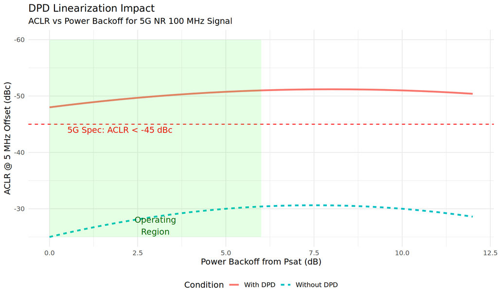

Figure 5.3: DPD Linearization Performance

# 3 Advanced Packaging & Integration

## 3.1 Packaging Evolution for RF PA

Modern PA modules demand **high integration** to reduce size, cost, and improve performance. Packaging has evolved from simple wire-bonded ceramic packages to advanced 3D integrated modules.

### 3.1.1 Package Types

#### 3.1.1.1 Ceramic Packages (Traditional)

**Examples**: Air-cavity ceramic, CuMo base

**Construction**: - GaN die on CuMo carrier - Gold wire bonds (25-50 µm diameter, multiple parallel for current) - Ceramic frame + lid - Metal flanges for heat sinking

**Advantages**: - Proven reliability - Excellent thermal conductivity (CuMo: 170 W/mK) - Low parasitic inductance (with proper wire bond design) - Hermetic sealing

**Disadvantages**: - Large footprint (10-20 mm per device) - Wire bond inductance limits frequency (difficult >10 GHz) - Assembly cost

**When to Use**: High-power base stations, military/aerospace

#### 3.1.1.2 Organic Packages (Overmolded)

**Examples**: QFN (Quad Flat No-lead), eLGA (enhanced Land Grid Array)

**Construction**: - GaN die on copper leadframe - Wire bonds or flip-chip - Molded epoxy encapsulation - Exposed thermal pad

**Advantages**: - Low cost (high-volume manufacturing) - Small size (3-8 mm) - SMT compatible (easy PCB assembly) - Good thermal performance with exposed pad

**Disadvantages**: - Moisture sensitivity (not hermetic) - Thermal resistance higher than ceramic - Limited power handling (<20W typical)

**When to Use**: Small cells, consumer devices, cost-sensitive applications

#### 3.1.1.3 Integrated Power Modules (IPM)

**Examples**: PAM_B mini-pac, Qorvo QPF series

**Construction**: - Multiple GaN dice (main, peak, driver) - Passive matching networks (L, C integrated) - Multi-layer organic substrate or LTCC - Overmold or metal lid

**Advantages**: - **System-in-package**: Complete PA system in one module - Optimized matching (short interconnects) - Reduced PCB complexity (customer-friendly) - Compact (10-15 mm square for 40W PA)

**Disadvantages**: - Higher module cost - Less flexibility (fixed matching) - Thermal management challenges (multiple heat sources)

**When to Use**: Massive MIMO, small cell, anywhere footprint-critical

#### 3.1.1.4 Advanced: Fan-Out Wafer-Level Packaging (FOWLP)

**Emerging Technology**: - GaN die + passives embedded in mold compound - Redistribution layer (RDL) for routing - Ultra-compact, thin profile (<1 mm)

**Potential**: - Lowest parasitic inductance (sub-100 pH) - Highest integration density - mmWave capable

**Challenges**: - High-power thermal dissipation (no thick substrate) - Warpage during molding (CTE mismatch) - GaN FOWLP immature (Si/GaAs more developed)

### 3.1.2 Thermal Management

**Critical Challenge**: GaN devices generate 100-200 W/mm² heat flux

#### 3.1.2.1 Thermal Resistance Path

From junction to ambient:
$$\theta_{JA} =
\theta_{JC} + \theta_{CS} + \theta_{SA}$$

Where: - $\theta_{JC}$ = Junction-to-case (device + package) - $\theta_{CS}$ = Case-to-sink (interface material) - $\theta_{SA}$ = Sink-to-ambient (heatsink, airflow)

**Typical Values** (40W PA module): - $\theta_{JC}$ = 1.5-3 °C/W (GaN device + package) - $\theta_{CS}$ = 0.2-0.5 °C/W (with thermal interface material) - $\theta_{SA}$ = 2-5 °C/W (depends on heatsink, fan) - **Total**: $\theta_{JA}$ = 4-8.5 °C/W

**Junction Temperature**:
$$T_J = T_A + P_{diss} \times
\theta_{JA}$$

For 40W output at 60% PAE: - $P_{DC}$ = 40W / 0.6 = 66.7W - $P_{diss}$ = 66.7W - 40W = 26.7W dissipated - $T_J$ = 50°C (ambient) + 26.7W × 6°C/W = **210°C**

**Thermal Design Challenge**: Keep $T_J < 200°C$ for GaN reliability

#### 3.1.2.2 Thermal Interface Materials (TIM)

| TIM Type | Thermal Conductivity | Thickness | θ_CS @ 1 cm² | Application |
| --- | --- | --- | --- | --- |
| Thermal grease | 3-8 W/mK | 25-100 µm | 0.3-1.3 °C/W | Lab testing |
| Thermal pads | 3-6 W/mK | 200-500 µm | 1-2.5 °C/W | Low-power |
| Phase change | 4-8 W/mK | 50-150 µm | 0.2-0.8 °C/W | Production |
| Solder | 50-80 W/mK | 50-150 µm | 0.02-0.06 °C/W | High-power |

**Best Practice**: Solder die to carrier for lowest θ_JC

#### 3.1.2.3 Heatsink Design

**Forced Air Cooling** (typical for base station): - Aluminum extrusion or copper spreader - Fins: 2-5 mm spacing, 20-40 mm height - Fan: 2-10 CFM per module - Achieves θ_SA = 2-4 °C/W

**Liquid Cooling** (ultra-high power): - Cold plate with microchannel - Water or glycol coolant - Achieves θ_SA = 0.2-0.5 °C/W - Required for >100W PA modules

### 3.1.3 Electrical Design Considerations

#### 3.1.3.1 Wire Bond Inductance

**Problem**: Each wire bond adds ~1 nH/mm length

For 2 mm wire bond:
$$L_{wire} \approx 2
\text{ nH}$$

At 3.5 GHz:
$$X_L = 2\pi f L = 44 \text{
Ω}$$

**Impact**: Significant impedance shift, gain loss

**Mitigation**: - Multiple parallel wire bonds (divide inductance) - Minimize bond length (low-profile die attach) - Use ribbon bonds (lower inductance than round wire) - For >10 GHz: Flip-chip or via transitions

#### 3.1.3.2 Ground Vias

**Critical for RF Performance**: - Multiple vias around device perimeter - Via diameter: 0.3-0.5 mm - Spacing: 0.8-1.5 mm (< λ/10) - Target via inductance: <0.2 nH

**Via Inductance Approximation**:
$$L_{via} \approx 0.2 h \left[
\ln\left(\frac{4h}{d}\right) + 1 \right] \text{ nH}$$

Where: - $h$ = PCB thickness (mm) - $d$ = Via diameter (mm)

Use **multiple parallel vias** to reduce effective inductance.

# 4 GaN Technology Evolution

## 4.1 Current GaN Technology

**Mainstream**: GaN-on-SiC (Gallium Nitride on Silicon Carbide substrate)

**Key Parameters** (state-of-the-art 2026): - Frequency range: DC to 50 GHz - Power density: 6-12 W/mm (S-band to X-band) - Efficiency: 60-75% PAE - Breakdown voltage: 100-200V - Thermal conductivity: 370 W/mK (SiC substrate)

**Mature Fabs**: - Qorvo (previously TriQuint) - Wolfspeed (Cree) - MACOM - NXP - Infineon

## 4.2 Emerging GaN Technologies

### 4.2.1 GaN-on-Si (Silicon Substrate)

**Motivation**: Lower cost than SiC substrate

**Status** (2026): - Commercially available for power electronics - RF performance improving but still behind GaN-on-SiC - Thermal conductivity limitation (Si: 150 W/mK vs SiC: 370 W/mK)

**Outlook**: - Cost-effective for <5 GHz, <20W applications - Will capture small cell market share - Unlikely to displace GaN-on-SiC for high-power base stations

### 4.2.2 GaN-on-Diamond

**Ultimate Thermal Solution**: - Diamond thermal conductivity: 2000 W/mK (5x better than SiC!) - Enables extreme power density: >20 W/mm

**Challenges**: - Diamond growth on GaN (lattice mismatch) - Cost (synthetic diamond expensive) - Manufacturing maturity (lab demos only as of 2026)

**Potential Applications**: - mmWave >28 GHz (Ka-band, V-band) - Ultra-compact phased arrays - Space applications (radiation hard + thermal)

**Timeline**: Commercial availability 2028-2030 (optimistic)

### 4.2.3 Vertical GaN

**Current GaN Limitation**: Lateral devices (source-drain on surface) - High on-resistance - Limited voltage scaling

**Vertical GaN** (like Si/SiC MOSFETs): - Current flows through substrate thickness - Much lower on-resistance - Higher voltage (>1000V possible) - Better thermal path

**Status**: Research phase, promising for power electronics

**RF Potential**: - Ultra-wideband operation (DC-18 GHz demonstrated) - Could revolutionize PA architecture

**Timeline**: 5-10 years to commercial RF devices

## 4.3 GaN vs GaAs vs Si LDMOS

Table 5.3: RF Power Amplifier Technology Comparison (2026)

| Parameter | GaN-on-SiC | GaAs | Si LDMOS | GaN-on-Si |
| --- | --- | --- | --- | --- |
| Max Frequency | 50 GHz | 100 GHz | 3.8 GHz | 10 GHz |
| Power Density | 10 W/mm | 1-2 W/mm | 2-4 W/mm | 4-6 W/mm |
| Efficiency | 65-75% | 45-60% | 55-65% | 60-70% |
| Voltage | 50-100V | 5-12V | 28-50V | 50-80V |
| Thermal Conduct. | 370 W/mK | 46 W/mK | 150 W/mK | 150 W/mK |
| Cost | High | Medium | Low | Medium-Low |
| Maturity | Mature | Very Mature | Very Mature | Emerging |
| Key Application | 5G macro BS | Handsets, mmWave | Low-cost BS | Small cell |

**Technology Selection Guide**:

- **Frequency < 2 GHz, Cost-sensitive**: Si LDMOS
- **2-6 GHz, High power (>20W)**: GaN-on-SiC
- **2-6 GHz, Low power (<10W)**: GaN-on-Si or GaAs
- **6-40 GHz, Any power**: GaN-on-SiC
- **>40 GHz, <5W**: GaAs (for now)
- **>40 GHz, >5W**: GaN-on-SiC or GaN-on-diamond (future)

# 5 6G & Future Technologies

## 5.1 6G Requirements (2030+ Deployment)

### 5.1.1 Frequency Bands

**Sub-7 GHz**: Similar to 5G - FR1: 450 MHz - 7.125 GHz - PA technology: GaN-on-SiC (mature)

**mmWave Extended**: - FR2: 24.25 - 71 GHz (extended from 5G’s 52.6 GHz) - FR3 (new): **7.125 - 24.25 GHz** (mid-band) - PA technology: GaN-on-SiC, GaN-on-diamond

**Sub-THz** (exploration): - 92-114.25 GHz (W-band) - 130-174.8 GHz (D-band) - PA technology: GaN, InP (Indium Phosphide), possibly graphene

### 5.1.2 Performance Targets

| Metric | 5G NR | 6G (Target) | PA Challenge |
| --- | --- | --- | --- |
| Peak Data Rate | 20 Gbps | 1 Tbps | Higher bandwidth → memory effects |
| PAPR | 9-12 dB | 10-15 dB | Even higher efficiency challenge |
| Modulation | 256-QAM | 1024-QAM, 4096-QAM | Extreme linearity (EVM <0.5%) |
| Spectrum Efficiency | 30 bps/Hz | 100+ bps/Hz | Wideband operation |
| Energy Efficiency | 1x | 10-100x | Average PAE must reach 45-55% |

**Key PA Challenge for 6G**: High efficiency at extreme backoff (12-15 dB)

## 5.2 Advanced PA Architectures for 6G

### 5.2.1 Dual-Input Doherty

**Innovation**: Separate inputs to main and peak amplifiers - Enables different signal processing per path - Asymmetric DPD (different models for main vs peak) - Bandwidth extension through per-path matching

**Advantage**: 5-10% efficiency gain over conventional Doherty

### 5.2.2 Load Modulated Balanced Amplifier (LMBA)

**Concept**: Combines load modulation with balanced amplifier - Four-port network (two inputs, two outputs) - Achieves wideband load modulation without quarter-wave lines - Demonstrated 60% fractional bandwidth

**Status**: Research → early products expected 2027-2028

**Potential**: Game-changer for ultra-wideband 6G

### 5.2.3 Outphasing Revival

**Modern Twist**: Digital control + adaptive combining - Addresses traditional outphasing issues (combiner loss) - Active load control using tunable matching - Software-defined load trajectories

**6G Application**: Sub-THz frequencies - Constant envelope → high-efficiency amplifier stages - Linearization through signal processing

### 5.2.4 Hybrid Analog-Digital Beamforming PA Arrays

**Massive MIMO Evolution**: - 64-256 antenna elements per panel - PA per element (low power, 0.25-1W each) - Combined beam steering (analog) + precoding (digital)

**PA Requirements**: - Ultra-compact (3-5 mm spacing) - Moderate linearity (beamforming averages distortion) - High efficiency at low power - Low cost (100s of PAs per base station)

**Technology**: GaN-on-Si + advanced packaging (FOWLP)

## 5.3 AI/ML in PA Design

Artificial Intelligence and Machine Learning are transforming PA design, optimization, and operation.

### 5.3.1 AI-Assisted Design Flow

**Traditional Design**: Manual iteration 1. Set specs → 2. Design matching → 3. Simulate → 4. Fab → 5. Measure → 6. Tune → Repeat

**AI-Enhanced Design**: 1. **Generative Design**: AI proposes initial matching networks 2. **Multi-Objective Optimization**: RL agent explores design space 3. **Predictive Simulation**: ML model predicts performance (faster than EM) 4. **Intelligent Tuning**: AI guides CV tuning process

**Benefits**: - 10x faster design cycle - Discovers non-intuitive solutions - Reduces prototype iterations

### 5.3.2 ML for DPD

**Traditional DPD**: Fixed polynomial model

**ML-Enhanced DPD**: - **Neural Network DPD**: Feedforward network learns PA inverse function - Architectures: LSTM (Long Short-Term Memory), GRU (Gated Recurrent Unit) - Captures complex memory effects better than polynomials - Demonstrated 3-5 dB ACLR improvement

- **Reinforcement Learning DPD**: Agent learns optimal predistortion policy
  - Adapts to changing PA characteristics
  - Multi-objective optimization (linearity + efficiency)

**Challenges**: - Training data requirements (10^6 - 10^7 samples) - Real-time inference (latency <1 ms) - FPGA implementation complexity

**Status** (2026): - Research → early commercial deployments - Xilinx Zynq UltraScale+ FPGA enables real-time NN-DPD

### 5.3.3 Self-Healing PA Systems

**Concept**: PA module that adapts to failures

**ML Role**: - **Anomaly Detection**: Identify performance degradation - Monitors: PAE, linearity, temperature, reflected power - Detects: Component failure, bias drift, thermal issues

- **Adaptive Reconfiguration**: Compensate for issues
  - Adjust bias points
  - Modify DPD model
  - Switch to backup paths (redundant PAs)
- **Predictive Maintenance**: Forecast failures before they occur
  - Analyze trends in monitored parameters
  - Alert for preventive action

**Value Proposition**: - Reduced downtime for base stations - Extended PA lifetime - Lower maintenance costs

**Deployment**: Cloud RAN architecture ideal for centralized ML

### 5.3.4 Digital Twin for PA

**Concept**: Virtual replica of physical PA module

**Components**: - **Physics-Based Model**: EM + thermal + nonlinear device - **Data-Driven Model**: ML trained on measurements - **Real-Time Sync**: Updates from actual PA telemetry

**Applications**: - **“What-If” Analysis**: Test scenarios before deployment - **Optimization**: Find optimal operating point in simulation - **Failure Analysis**: Replay conditions leading to issue

**Implementation**: - Cloud-hosted digital twin - Edge device reports telemetry - Twin runs 100-1000x faster than real-time

# 6 Summary & Key Takeaways

## 6.1 Efficiency Enhancement Techniques

**Doherty PA**: - ✅ Proven, mature technology - ✅ 50% PAE at 6 dB backoff (vs 30% for Class AB) - ✅ Moderate complexity and cost - ❌ Limited bandwidth (10-30%) - **Best for**: Sub-6 GHz macro base stations

**Envelope Tracking**: - ✅ Superior efficiency (55%+ average PAE possible) - ✅ Wideband capable (40-60% fractional BW) - ❌ High complexity (supply modulator required) - ❌ Time alignment critical - **Best for**: Wideband systems, high-power (>40W)

**Outphasing**: - ✅ Constant envelope → simple PAs - ❌ Combiner losses - ❌ Signal decomposition complexity - **Best for**: Specialized applications, sub-THz

## 6.2 Linearization

**DPD is Essential** for modern PAs: - Enables 10-20 dB ACLR improvement - Allows operation closer to compression → higher efficiency - Memory polynomial sufficient for most 5G applications - Real-time adaptation becoming standard

**Next Generation**: Neural network DPD - Better linearity (3-5 dB ACLR gain) - Adaptive to changing conditions - Requires FPGA/ASIC for inference

## 6.3 Packaging & Integration

**Trend**: Higher integration (system-in-package) - Multiple devices + matching in one module - Reduces PCB complexity - Enables compact designs (massive MIMO)

**Thermal Management** is critical: - GaN power density demands excellent heat sinking - Target: $T_J < 200°C$ for reliability - Solder attach + forced air typical for base station

## 6.4 Future Outlook

**6G Challenges**: - Even higher PAPR (12-15 dB) → efficiency at extreme backoff - 1024-QAM, 4096-QAM → ultra-high linearity (EVM <0.5%) - Sub-THz frequencies → new PA architectures - Energy efficiency 10-100x improvement needed

**Enabling Technologies**: - GaN-on-diamond (thermal performance) - Vertical GaN (wideband, high voltage) - Advanced packaging (FOWLP for mmWave) - AI/ML for design, optimization, adaptation

**AI/ML Impact**: - Faster design cycles (generative design) - Better DPD (neural networks) - Self-healing systems (anomaly detection) - Digital twins (virtual testing)

## 6.5 Recommended Reading

1. **Doherty PA Design**:
   - Cripps, S. C., “Advanced Techniques in RF Power Amplifier Design”, Artech House, 2002
   - Raab, F. H., “Efficiency of Doherty RF Power-Amplifier Systems”, IEEE Trans. Broadcasting, 1987
2. **Envelope Tracking**:
   - Kim, J., et al., “Wideband Envelope Tracking Power Amplifiers With Reduced Bandwidth Power Supply Waveforms and Adaptive Digital Predistortion Techniques”, IEEE Trans. Microwave Theory Tech., 2009
3. **DPD**:
   - Wood, J., “Behavioral Modeling and Linearization of RF Power Amplifiers”, Artech House, 2014
   - Morgan, D. R., et al., “A Generalized Memory Polynomial Model for Digital Predistortion of RF Power Amplifiers”, IEEE Trans. Signal Processing, 2006
4. **GaN Technology**:
   - Mishra, U. K., Shen, L., Kazior, T. E., Wu, Y.-F., “GaN-Based RF Power Devices and Amplifiers”, Proc. IEEE, 2008
   - Pengelly, R. S., et al., “A Review of GaN on SiC High Electron-Mobility Power Transistors and MMICs”, IEEE Trans. Microwave Theory Tech., 2012
5. **Future Technologies**:
   - Viikari, V., et al., “Beamforming and Enabling Technologies for 6G”, IEEE Communications Standards Magazine, 2024
   - Zhang, H., et al., “Artificial Intelligence for 6G Wireless Systems”, IEEE Wireless Communications, 2025

**Chapter 5 Complete**  
**Next**: Chapter 6: Lessons Learned & Practical Wisdom →